# Biostat M280 Homework 4

Due Mar 16 @ 11:59PM

Emilie Campos

Our Apache Yarn cluster hosts the [flights](http://stat-computing.org/dataexpo/2009/the-data.html) data representing 123 million flights over 22 years. Read the [lecture notes](http://hua-zhou.github.io/teaching/biostatm280-2018winter/slides/12-sparklyr/sparklyr-flights.html) on how to access the Yarn cluster. Connect to the database using `sparklyr` and answer following questions. You can base your answers on a specific year or the whole data set.

# Busiest Airports

Map the top 10 busiest airports. Size of dots should reflect the number of flights through that destination. Hint: You may find this tutorial on [Making Maps in R](http://eriqande.github.io/rep-res-web/lectures/making-maps-with-R.html) helpful.

The top 10 busiest airports are all in the United States:

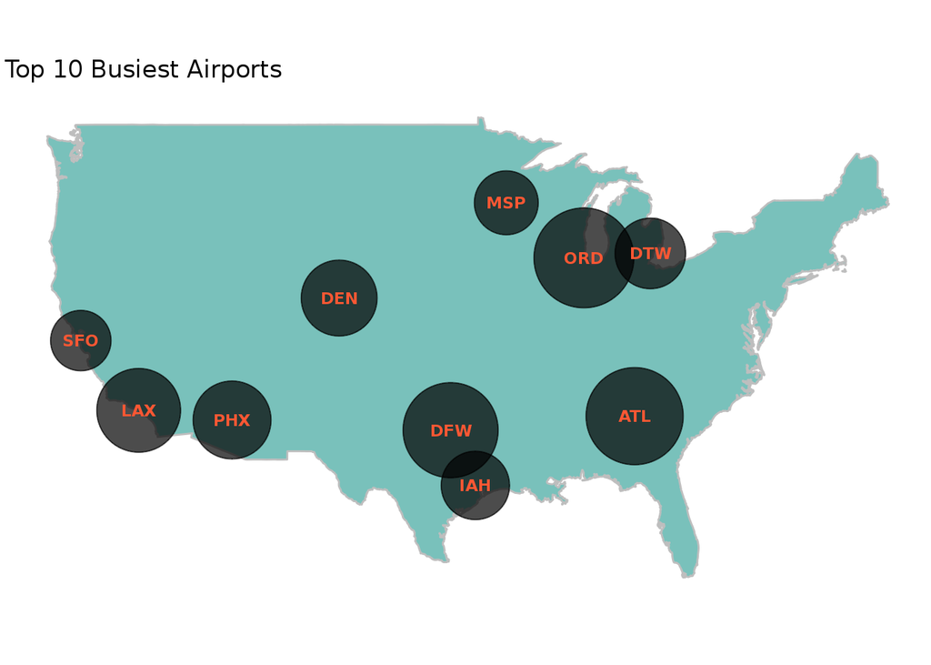

# Busiest Routes

Map the top 10 busiest direct routes. Size of lines should reflect the number of flights through that route.

Again, the busiest routes are within the United States:

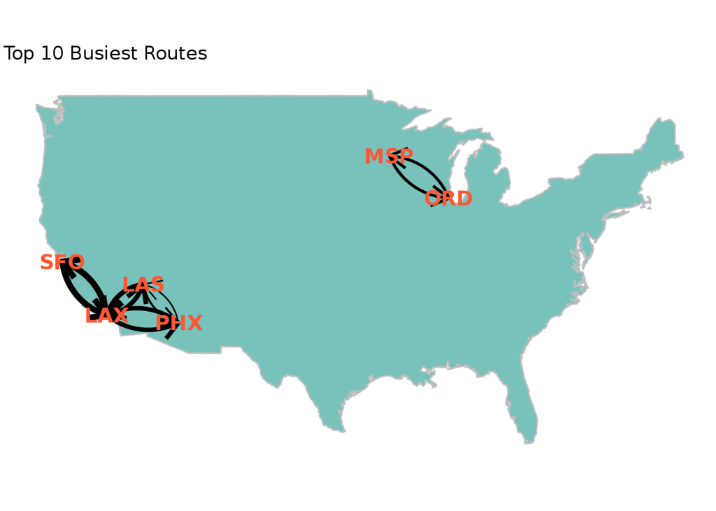

# LAX:

## Reproduce plot.

Visualize and explain some prominent features you observe. For example, what happened at points 1-5?

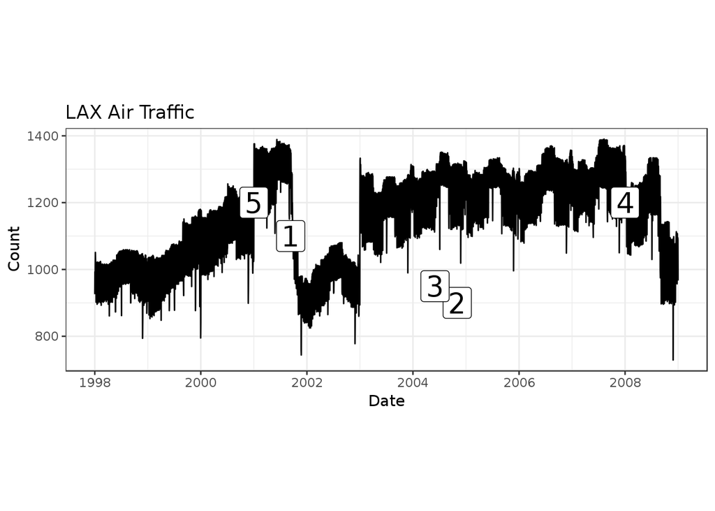

| Point | Possible Explanation |
| --- | --- |
| 1 | Two airplanes were hijacked and flew into the Twin Towers which tightend airport security and heightened fear of flying. |
| 2 | This seems to be close to Thanksgiving 2004 so people may not be flying as much on a holiday. There seem to be similar dips in other years. |
| 3 | This seems to be close to 4th of July 2004 so again, maybe people aren’t flying as much when they could be BBQ-ing. |
| 4 | There was a recession. Jet fuel was expensive and airlines were trying to raise the price of flights. This caused a dip in flights for the rest of the year. |
| 5 | From some Googling, it appears LAX underwent some renovations beginning in 2000 which could attract more flyers. |

## Visualize and explain seasonal effects.

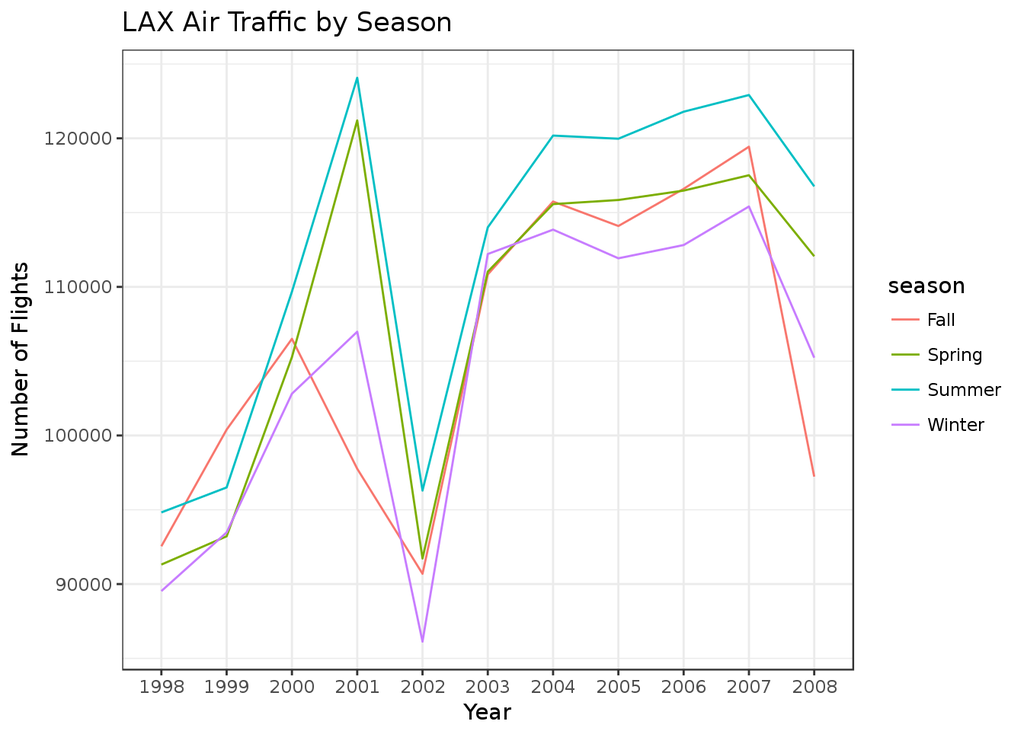

## Visualize and explain weekly effects.

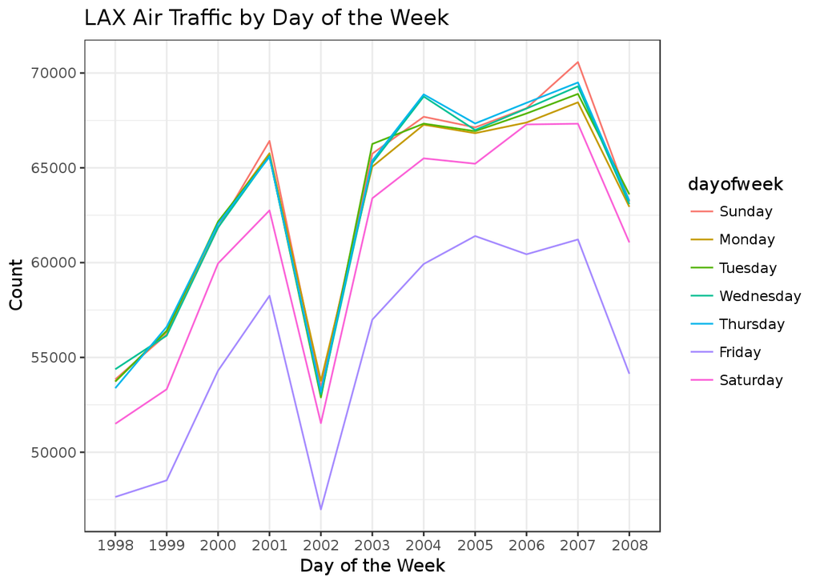

There are consistently fewer flights on Fridays and Saturdays. If we are speculating, this could be because people want to travel on a weekday in order to enjoy their vacations on the weekend, or it could be because businesspeople fly on workdays.

## Map top 10 destinations from LAX.

Size of dots should reflect the number of flights from LAX to that destination.

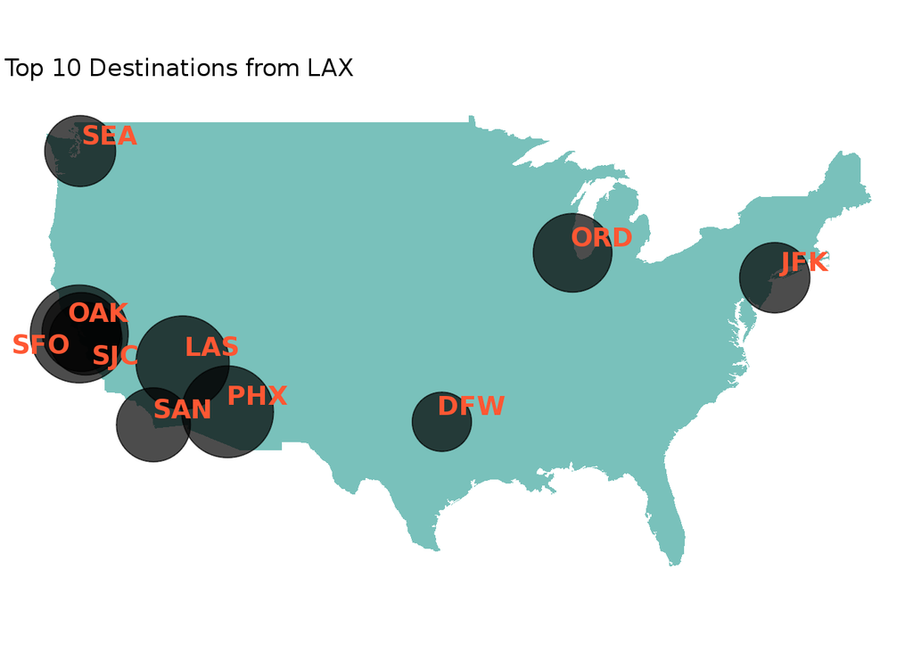

# Arrival Delay Prediction

Build a predictive model for the arrival delay (`arrdelay`) of flights flying from LAX. Use the same filtering criteria as in the [lecture notes](http://hua-zhou.github.io/teaching/biostatm280-2018winter/slides/12-sparklyr/sparklyr-flights.html) to construct training and validation sets. You are allowed to use a maximum of 5 predictors. The prediction performance of your model on the validation data set will be an important factor for grading this question.

```
## Call: ml_linear_regression.tbl_spark(., arrdelay ~ distance + depdelay + uniquecarrier)
##
## Deviance Residuals (approximate):
##      Min       1Q   Median       3Q      Max
## -193.787   -7.074   -1.377    5.197  332.139
##
## Coefficients:
##      (Intercept)         distance         depdelay uniquecarrier_WN
##      -0.69481192      -0.00308328       1.01217764      -1.93405615
## uniquecarrier_OO uniquecarrier_AA uniquecarrier_UA uniquecarrier_DL
##       0.74734641       3.52663710       1.34094813       3.48834362
## uniquecarrier_AS uniquecarrier_MQ uniquecarrier_CO uniquecarrier_NW
##       0.07762555       0.13152935       4.92376907       1.26046455
## uniquecarrier_US uniquecarrier_HP uniquecarrier_XE uniquecarrier_F9
##       2.26862299       0.23483827       1.85339215       2.09218498
## uniquecarrier_TZ uniquecarrier_FL uniquecarrier_EV uniquecarrier_YV
##       5.18135737       2.98744942       0.89537424       0.21310320
## uniquecarrier_HA uniquecarrier_DH
##       0.18129594      11.80158875
##
## R-Squared: 0.8852
## Root Mean Squared Error: 13.33
```

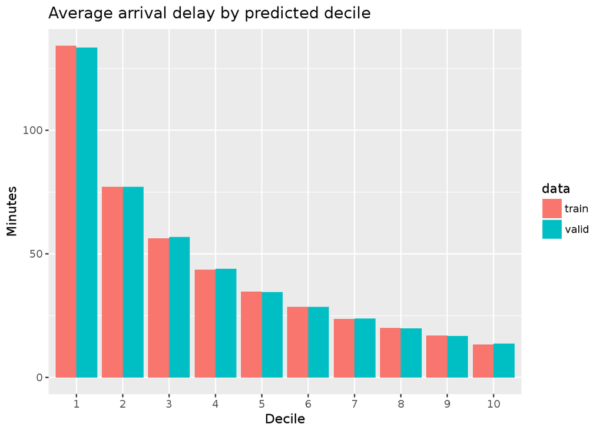

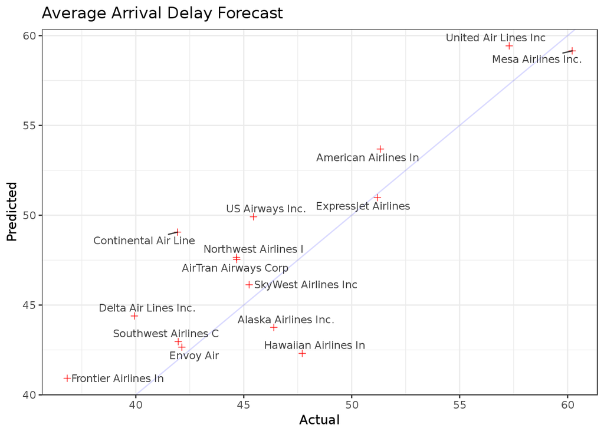

# Other Insights

Visualize and explain any other information you want to explore.

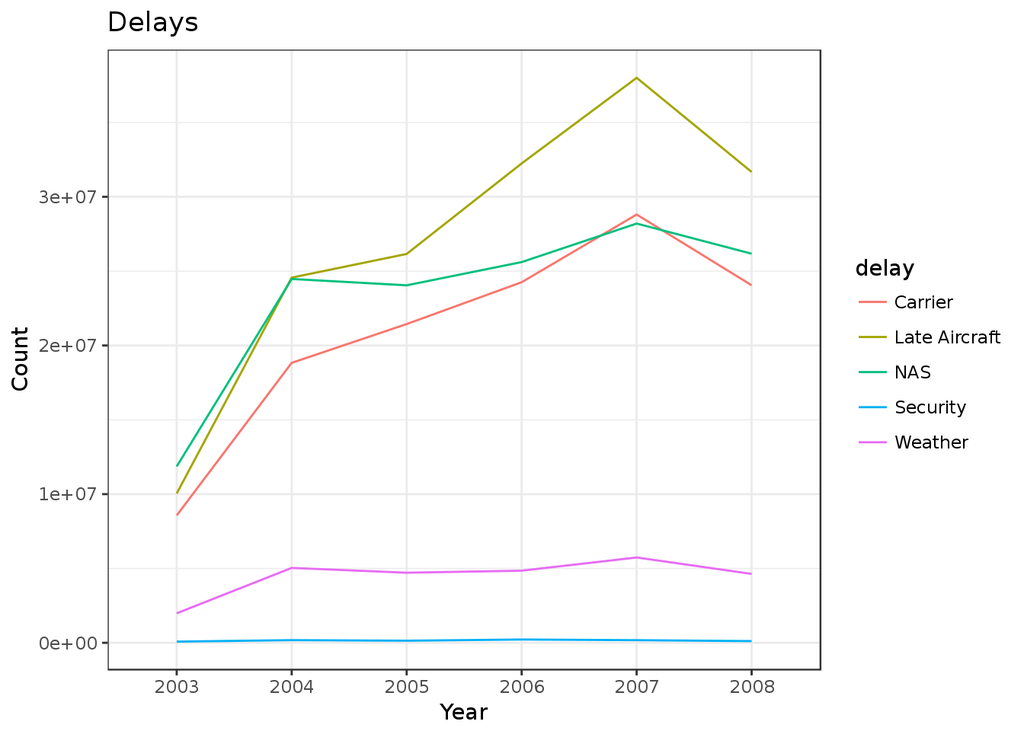

Surprisingly, most delays were not caused by security or weather, but mainly by NAS and late aircraft.